# Experiments, Central Limit Theorem, Confindence Intervals

# 1 Simulating Experiments

In this problem we will simulate two important experiments: coin tosses and die rolls.

We will explore empirical probability of events using random samples. The two important functions to understand are “sample” and “replicate”.

We use the sample function to set up our experiment, and replicate function to repeat it as many times as we want.

## 1.1 Die Rolls

Setup the experiment where we roll two fair six sided die independently, and calculate the sum of the numbers that appear for each of them.

Use the replicate function to repeat this experiment 10000 times, store the output of the experiment in a variable “sum_die”.

Use “sum_die” to calculate the empirical probability of getting the sums 2, 3, 4, …, 12. Compare your answers with the theoretical values (you calculated these in HW2).

Plot the following: relative frequency of getting sum equal to 4 as a function of number of trials, for this experiment.

## 1.2 Balls and Cells

If $n$ indistinguishable balls are placed randomly into $n$ cells, the probability that exactly one cell remains empty is calculated to be
$${n\choose 2} \frac{n!}{n^n}.$$

\

Write a function “exactly_one_cell’’ takes input $n$, and performs one run of this experiment. Hint: the”unique” function applied to a vector gives the unique entries in a vector. You can sample a set of size $n$ (with replacement) from ${1, 2, 3, 4, 5, ...., n}$, and check if the number of unique entries in this set is $(n-1)$.

```r
#define the function 'exactly_one_cell'sds
#takes input number of cells,
#output: true if exactly one cell is empty, else false.
```

```r
n <- 3
#balls_to_cell_exp <- replicate(100000, exactly_one_cell(n))
#mean(balls_to_cell_exp)
theoretical_value <- choose(n, 2)*factorial(n)/(n^n)
theoretical_value
```

```
## [1] 0.6666667
```

Now use the replicate function to calculate the empirical probabilities when for each of the following values of $n: 3, 6, 9, 15$ (note any problems that you might run into). Verify that your empirical probabilities indeed line up with what we expect from our theoretical calculations.

# 2 Central Limit Theorem

## 2.1 Exponential Distribution

Use the replicate function to get the histograms for the sampling distribution of the sample mean when working with sample sizes $n = 1, 2, 3, 4, 15, 500$. Be sure to have appropriate titles for your histograms.

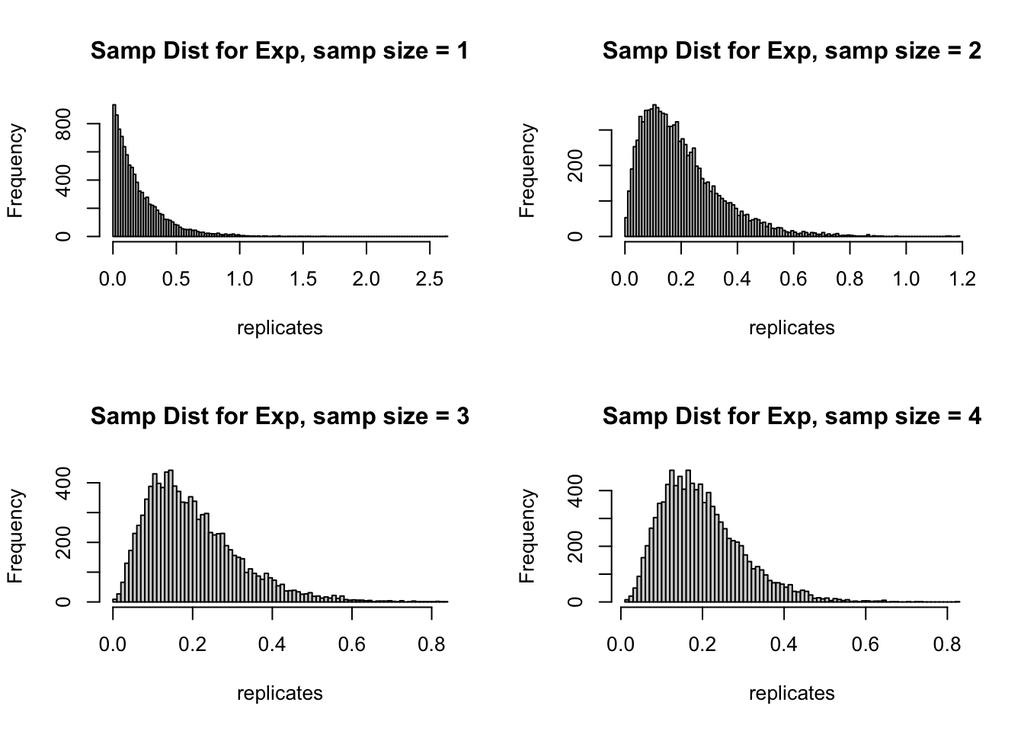

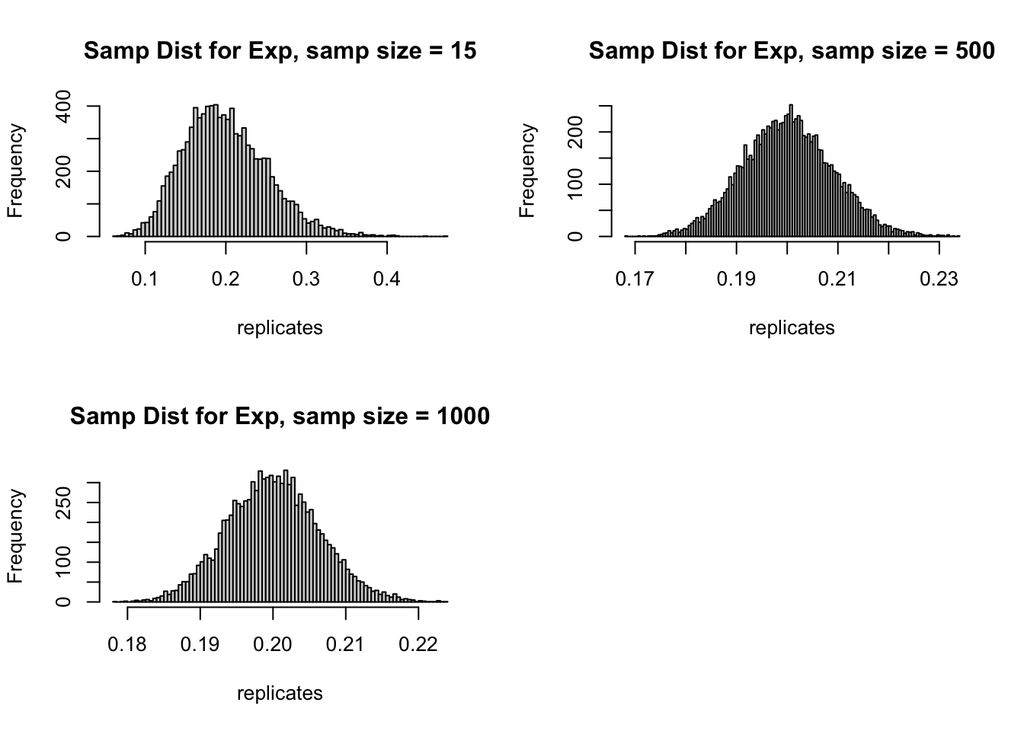

```r
  samp_sizes  <- c(1, 2, 3, 4, 15, 500, 1000)

  par(mfrow=c(2,2))
  for(size in samp_sizes){
    replicates <- replicate(10000, {
      mean(rexp(size, rate = 5))
    })
    hist(replicates, breaks = 100,
         main = paste("Samp Dist for Exp, samp size =", size ))
}
```

What do you notice?